# Homework 7

Han Siyue 17307110012

2019/12/2

## Exercise 7.10

In Example 7.18, leave-one-out ($n$-fold) cross validation was used to select the best fitting model. Repeat the analysis replacing the Log-Log model with a cubic polynomial model. Which of the four models is selected by the cross validation procedure? Which model is selected according to maximum adjusted $R^2$?

```r
library(DAAG); attach(ironslag)
```

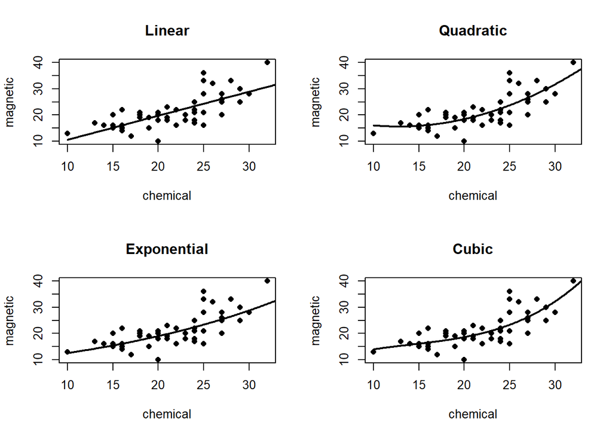

```r
a <- seq(10, 40, .1)     #sequence for plotting fits

par(mfrow = c(2, 2))    #layout for graphs

L1 <- lm(magnetic ~ chemical)
plot(chemical, magnetic, main="Linear", pch=16)
yhat1 <- L1$coef[1] + L1$coef[2] * a
lines(a, yhat1, lwd=2)

L2 <- lm(magnetic ~ chemical + I(chemical^2))
plot(chemical, magnetic, main="Quadratic", pch=16)
yhat2 <- L2$coef[1] + L2$coef[2] * a + L2$coef[3] * a^2
lines(a, yhat2, lwd=2)

L3 <- lm(log(magnetic) ~ chemical)
plot(chemical, magnetic, main="Exponential", pch=16)
logyhat3 <- L3$coef[1] + L3$coef[2] * a
yhat3 <- exp(logyhat3)
lines(a, yhat3, lwd=2)

L4 <- lm(magnetic ~ chemical + I(chemical^2) + I(chemical^3))
plot(chemical, magnetic, main="Cubic", pch=16)
yhat4 <- L4$coef[1] + L4$coef[2] * a + L4$coef[3] * a^2 + L4$coef[4] * a^3
lines(a, yhat4, lwd=2)
```

```r
n <- length(magnetic)   #in DAAG ironslag
e1 <- e2 <- e3 <- e4 <- numeric(n)

# for n-fold cross validation
# fit models on leave-one-out samples
for (k in 1:n) {
  y <- magnetic[-k]
  x <- chemical[-k]

  J1 <- lm(y ~ x)
  yhat1 <- J1$coef[1] + J1$coef[2] * chemical[k]
  e1[k] <- magnetic[k] - yhat1

  J2 <- lm(y ~ x + I(x^2))
  yhat2 <- J2$coef[1] + J2$coef[2] * chemical[k] +
    J2$coef[3] * chemical[k]^2
  e2[k] <- magnetic[k] - yhat2

  J3 <- lm(log(y) ~ x)
  logyhat3 <- J3$coef[1] + J3$coef[2] * chemical[k]
  yhat3 <- exp(logyhat3)
  e3[k] <- magnetic[k] - yhat3

  J4 <- lm(y ~ x + I(x^2) + I(x^3))
  yhat4 <- J4$coef[1] + J4$coef[2] * chemical[k] +
    J4$coef[3] * chemical[k]^2 + J4$coef[4] * chemical[k]^3
  e4[k] <- magnetic[k] - yhat4
}

c(mean(e1^2), mean(e2^2), mean(e3^2), mean(e4^2))
```

```
## [1] 19.55644 17.85248 18.44188 18.17756
```

```r
c(summary(L1)$adj.r.squared, summary(L2)$adj.r.squared, summary(L3)$adj.r.squared, summary(L4)$adj.r.squared)
```

```
## [1] 0.5281545 0.5768151 0.5280556 0.5740396
```

## Exercise 7.11

In Example 7.18, leave-one-out ($n$-fold) cross validation was used to select the best fitting model. Use leave-two-out cross validation to compare the models.

```r
n <- length(magnetic)   #in DAAG ironslag

# for n-fold cross validation
# fit models on leave-two-out samples
ij <- cbind(rep(1:n, each = n), rep(1:n, n))
ij <- ij[ij[, 1] != ij[, 2], ]  # all pairs of 1:n and 1:n
e1 <- e2 <- e3 <- e4 <- e5 <- numeric(length(ij))

for (k in 1:(length(ij)/2)) {
  i <- ij[k, 1]
  j <- ij[k, 2]
  y <- magnetic[-c(i, j)]
  x <- chemical[-c(i, j)]

  J1 <- lm(y ~ x)
  yhat1 <- J1$coef[1] + J1$coef[2] * chemical[i]
  e1[2*k-1] <- magnetic[i] - yhat1
  yhat1 <- J1$coef[1] + J1$coef[2] * chemical[j]
  e1[2*k] <- magnetic[j] - yhat1

  J2 <- lm(y ~ x + I(x^2))
  yhat2 <- J2$coef[1] + J2$coef[2] * chemical[i] +
    J2$coef[3] * chemical[i]^2
  e2[2*k-1] <- magnetic[i] - yhat2
  yhat2 <- J2$coef[1] + J2$coef[2] * chemical[j] +
    J2$coef[3] * chemical[j]^2
  e2[2*k] <- magnetic[j] - yhat2

  J3 <- lm(log(y) ~ x)
  logyhat3 <- J3$coef[1] + J3$coef[2] * chemical[i]
  yhat3 <- exp(logyhat3)
  e3[2*k-1] <- magnetic[i] - yhat3
  logyhat3 <- J3$coef[1] + J3$coef[2] * chemical[j]
  yhat3 <- exp(logyhat3)
  e3[2*k] <- magnetic[j] - yhat3

  J4 <- lm(log(y) ~ log(x))
  logyhat4 <- J4$coef[1] + J4$coef[2] * log(chemical[i])
  yhat4 <- exp(logyhat4)
  e4[2*k-1] <- magnetic[i] - yhat4
  logyhat4 <- J4$coef[1] + J4$coef[2] * log(chemical[j])
  yhat4 <- exp(logyhat4)
  e4[2*k] <- magnetic[j] - yhat4

  J5 <- lm(y ~ x + I(x^2) + I(x^3))
  yhat5 <- J5$coef[1] + J5$coef[2] * chemical[i] +
    J5$coef[3] * chemical[i]^2 + J5$coef[4] * chemical[i]^3
  e5[2*k-1] <- magnetic[i] - yhat5
  yhat5 <- J5$coef[1] + J5$coef[2] * chemical[j] +
    J5$coef[3] * chemical[j]^2 + J5$coef[4] * chemical[j]^3
  e5[2*k] <- magnetic[j] - yhat5
}

c(mean(e1^2), mean(e2^2), mean(e3^2), mean(e4^2), mean(e5^2))
```

```
## [1] 19.57227 17.87018 18.45491 20.46718 18.23498
```

Quadratic model and Cubic model still perform better than the other three models.

## Project 7.A

Conduct a Monte Carlo study to estimate the coverage probabilities of the standard normal bootstrap conﬁdence interval, the basic bootstrap conﬁdence interval, and the percentile conﬁdence interval. Sample from a normal population and check the empirical coverage rates for the sample mean. Find the proportion of times that the conﬁdence intervals miss on the left, and the porportion of times that the conﬁdence intervals miss on the right.

```r
set.seed(123)
n <- 500 #number of data
B <- 200
m <- 1000 #number of repetition of real cases

theta.star <- numeric(B)
alpha <- c(.025, .975)
ci.normal <- ci.basic <- ci.percentile <- matrix(0, m, 2)
theta.hat <- numeric(m)

for (i in 1:m){
  data <- rnorm(n) #one case of sample from a normal population
  theta.hat[i] <- mean(data) #sample mean
  #bootstrap
  for (b in 1:B){
    data.sample <- sample(1:n, size = n, replace = TRUE)
    data.star <- data[data.sample]
    theta.star[b] <- mean(data.star)
  }
  #calculations for bootstrap confidence intervals
  ci.normal[i, ] <- theta.hat[i] + qnorm(alpha) * sd(theta.star)
  ci.basic[i, ] <- 2 * theta.hat[i] -
    quantile(theta.star, rev(alpha), type=1)
  ci.percentile[i, ] <- quantile(theta.star, alpha, type=6)
}

#check the empirical coverage rates
ci.rate.normal <- mean(ci.normal[, 1] < 0 & ci.normal[, 2] > 0)
ci.rate.basic <- mean(ci.basic[, 1] < 0 & ci.basic[, 2] > 0)
ci.rate.percentile <- mean(ci.percentile[, 1] < 0 & ci.percentile[, 2] > 0)

#confidence intervals miss on the left
ci.rate.normal.left <- mean(ci.normal[, 2] < 0) / (1-ci.rate.normal)
ci.rate.basic.left <- mean(ci.basic[, 2] < 0) / (1-ci.rate.basic)
ci.rate.percentile.left <- mean(ci.percentile[, 2] < 0) / (1-ci.rate.percentile)

#confidence intervals miss on the right
ci.rate.normal.right <- mean(ci.normal[, 1] > 0) / (1-ci.rate.normal)
ci.rate.basic.right <- mean(ci.basic[, 1] > 0) / (1-ci.rate.basic)
ci.rate.percentile.right <- mean(ci.percentile[, 1] > 0) / (1-ci.rate.percentile)

#output the result
output <- matrix(c(ci.rate.normal,ci.rate.basic,ci.rate.percentile,ci.rate.normal.left,ci.rate.basic.left,ci.rate.percentile.left,ci.rate.normal.right,ci.rate.basic.right,ci.rate.percentile.right), 3, 3)
output <- as.data.frame(output, row.names = c("normal","basic","percentile"))
names(output) <- c("coverage rate", "miss on the left", "miss on the right")
output
```

```
##            coverage rate miss on the left miss on the right
## normal             0.935        0.5076923         0.4923077
## basic              0.931        0.4347826         0.5652174
## percentile         0.936        0.5000000         0.5000000
```

## Project 7.B

Repeat Project 7.A for the sample skewness statistic. Compare the coverage rates for normal populations (skewness 0) and $\chi^2(5)$ distributions (positive skewness).

```r
set.seed(123)
n <- 500 #number of data
B <- 200
m <- 1000 #number of repetition of real cases

theta.star <- numeric(B)
alpha <- c(.025, .975)
ci.normal <- ci.basic <- ci.percentile <- matrix(0, m, 2)
theta.hat <- numeric(m)

sk <- function(x) {
  #computes the sample skewness coeff.
  xbar <- mean(x)
  m3 <- mean((x - xbar)^3)
  m2 <- mean((x - xbar)^2)
  return( m3 / m2^1.5 )
}

for (i in 1:m){
  data <- rnorm(n) #sample from a normal population
  theta.hat[i] <- sk(data) #skewness
  #bootstrap
  for (b in 1:B){
    data.sample <- sample(1:n, size = n, replace = TRUE)
    data.star <- data[data.sample]
    theta.star[b] <- sk(data.star)
  }
  #calculations for bootstrap confidence intervals
  ci.normal[i, ] <- theta.hat[i] + qnorm(alpha) * sd(theta.star)
  ci.basic[i, ] <- 2 * theta.hat[i] -
    quantile(theta.star, rev(alpha), type=1)
  ci.percentile[i, ] <- quantile(theta.star, alpha, type=6)
}

#check the empirical coverage rates
ci.rate.normal <- mean(ci.normal[, 1] < 0 & ci.normal[, 2] > 0)
ci.rate.basic <- mean(ci.basic[, 1] < 0 & ci.basic[, 2] > 0)
ci.rate.percentile <- mean(ci.percentile[, 1] < 0 & ci.percentile[, 2] > 0)

#confidence intervals miss on the left
ci.rate.normal.left <- mean(ci.normal[, 2] < 0) / (1-ci.rate.normal)
ci.rate.basic.left <- mean(ci.basic[, 2] < 0) / (1-ci.rate.basic)
ci.rate.percentile.left <- mean(ci.percentile[, 2] < 0) / (1-ci.rate.percentile)

#confidence intervals miss on the right
ci.rate.normal.right <- mean(ci.normal[, 1] > 0) / (1-ci.rate.normal)
ci.rate.basic.right <- mean(ci.basic[, 1] > 0) / (1-ci.rate.basic)
ci.rate.percentile.right <- mean(ci.percentile[, 1] > 0) / (1-ci.rate.percentile)

#output the result
output <- matrix(c(ci.rate.normal,ci.rate.basic,ci.rate.percentile,ci.rate.normal.left,ci.rate.basic.left,ci.rate.percentile.left,ci.rate.normal.right,ci.rate.basic.right,ci.rate.percentile.right), 3, 3)
output.normal <- as.data.frame(output, row.names = c("normal","basic","percentile"))
names(output.normal) <- c("coverage rate", "miss on the left","miss on the right")
print("normal case"); print(output.normal)
```

```
## [1] "normal case"
```

```
##            coverage rate miss on the left miss on the right
## normal             0.929        0.4507042         0.5492958
## basic              0.924        0.4210526         0.5789474
## percentile         0.929        0.4366197         0.5633803
```

```r
set.seed(123)
n <- 500 #number of data
B <- 200
m <- 1000 #number of repetition of real cases

theta.star <- numeric(B)
alpha <- c(.025, .975)
ci.normal <- ci.basic <- ci.percentile <- matrix(0, m, 2)
theta.hat <- numeric(m)

sk <- function(x) {
  #computes the sample skewness coeff.
  xbar <- mean(x)
  m3 <- mean((x - xbar)^3)
  m2 <- mean((x - xbar)^2)
  return( m3 / m2^1.5 )
}

for (i in 1:m){
  data <- rchisq(n, df=5) #sample from a chi-square population
  theta.hat[i] <- sk(data) #skewness
  #bootstrap
  for (b in 1:B){
    data.sample <- sample(1:n, size = n, replace = TRUE)
    data.star <- data[data.sample]
    theta.star[b] <- sk(data.star)
  }
  #calculations for bootstrap confidence intervals
  ci.normal[i, ] <- theta.hat[i] + qnorm(alpha) * sd(theta.star)
  ci.basic[i, ] <- 2 * theta.hat[i] -
    quantile(theta.star, rev(alpha), type=1)
  ci.percentile[i, ] <- quantile(theta.star, alpha, type=6)
}
theta.real <- mean(theta.hat)

#check the empirical coverage rates
ci.rate.normal <- mean(ci.normal[, 1] < theta.real & ci.normal[, 2] > theta.real)
ci.rate.basic <- mean(ci.basic[, 1] < theta.real & ci.basic[, 2] > theta.real)
ci.rate.percentile <- mean(ci.percentile[, 1] < theta.real & ci.percentile[, 2] > theta.real)

#confidence intervals miss on the left
ci.rate.normal.left <- mean(ci.normal[, 2] < theta.real) / (1-ci.rate.normal)
ci.rate.basic.left <- mean(ci.basic[, 2] < theta.real) / (1-ci.rate.basic)
ci.rate.percentile.left <- mean(ci.percentile[, 2] < theta.real) / (1-ci.rate.percentile)

#confidence intervals miss on the right
ci.rate.normal.right <- mean(ci.normal[, 1] > theta.real) / (1-ci.rate.normal)
ci.rate.basic.right <- mean(ci.basic[, 1] > theta.real) / (1-ci.rate.basic)
ci.rate.percentile.right <- mean(ci.percentile[, 1] > theta.real) / (1-ci.rate.percentile)

#output the result
output <- matrix(c(ci.rate.normal,ci.rate.basic,ci.rate.percentile,ci.rate.normal.left,ci.rate.basic.left,ci.rate.percentile.left,ci.rate.normal.right,ci.rate.basic.right,ci.rate.percentile.right), 3, 3)
output.chi <- as.data.frame(output, row.names = c("normal","basic","percentile"))
names(output.chi) <- c("coverage rate", "miss on the left","miss on the right")
print("chi-square case"); print(output.chi)
```

```
## [1] "chi-square case"
```

```
##            coverage rate miss on the left miss on the right
## normal             0.866        0.8656716         0.1343284
## basic              0.861        0.7769784         0.2230216
## percentile         0.872        0.8984375         0.1015625
```